# Assignment 2

## Introduction/Review of Tidyverse

- Tidyverse: a collection of open source packages for the R programming language introduced by Hadley Wickham and his team that “share an underlying design philosophy, grammar, and data structures” of tidy data. (Wikipedia)
- Widely used approach to data science in R

[figure not shown]

## A “Meta-package” of packages

[figure not shown]

## Resources to learn Tidyverse

- Links embedded in the assignment
- R for Data Science: https://r4ds.hadley.nz/intro
- Data Carpentry: https://datacarpentry.org/R-ecology-lesson

## Science Question

How does water quality (temperature and chlorophyll-a) vary across time and among drinking water reservoirs in the Roanoke region?

## Science Question

- Chlorophyll-a is a pigment in plants, algae, and cyanobacteria that used in photosynthesis. It is a metric of how much algae is present in the lake or reservoir.
- Too much cause aesthetic problems such as green scums and bad odors, and can result in decreased levels of dissolved oxygen. (U.S. EPA)
- Some algae and cyanobacteria also produce toxins that can be of public health concern when they are found in high concentrations. (U.S. EPA)

https://www.epa.gov/national-aquatic-resource-surveys/indicators-chlorophyll

## Data

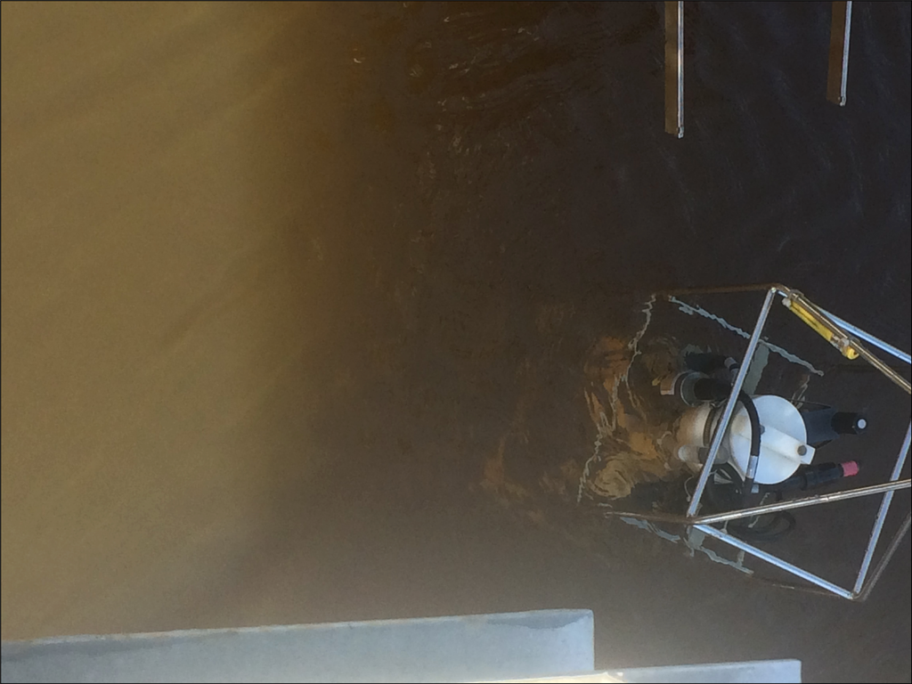

Photo credit: Cayelan Carey

## Data

A CTD (Conductivity, Temperature, and Depth) sensor is lowered in the water column and uses sensors to measure different water quality variables throughout the water column.

## Data

CSV data is available through the Environmental Data Initiative repository

[figure not shown]

## Data

The data are from the National Science Foundation funded Virginia Reservoirs Long-Term Research in Environmental Biology site.

[figure not shown]

## Reservoirs

[interactive chart not shown]

## Assignment

The assignment is designed to help you review R tidyverse skills that were introduced before the course.

- Accept (e.g., fork) assignment
- Clone your accepted assignment repo to your computer
- Work on assignment (many commits expected)
- Push assignment to GitHub (many times - this a backup)
- Final render of the document to HTML
- Commit and push HTML to GitHub
- Upload HTML to Canvas

## R house keeping

- Tools - > Global Options…
- General: Uncheck Restore .RData
- General: set Save workspace on exit to Never
- Code: Check “Use native pipe”